# College Scorecard Data Analysis (Fall '17 - '18)

#### About

This project aims to conduct a high level survey of the US Education System as of the academic year 2017 - 2018. Our analysis will be structured. In that, we will follow a question and answer format. First we will pose a question; then we will use Python and its Data Processing libraries to create informative Visualizations and relevant Summary Statistics that try to answer our question. Initially we will stick to answering questions about a single variable at a time, followed by two at a time and finally broaden our perspective to consider interaction between three or more variables.

#### The Data

The Data used here was gathered under the [College Scorecard Project](https://collegescorecard.ed.gov/) by the U. S. Department of Education.  
The College Scorecard Project was inititated in a bid to increase transparency, putting the power in the hands of students and families to compare how well individual postsecondary institutions were preparing their students to be successful. This project provided data to help students and families compare college costs and outcomes as they weighed the tradeoffs of different colleges, accounting for their own needs and educational goals.

## Wrangling the Data

For this analysis, we will be using the data for the **Academic Year 2017-18** as reported by all the [Integrated Postsecondary Education Data System (IPEDS)](https://nces.ed.gov/ipeds/) institutions.  
The data resides in a csv file called: `MERGED2017_18_PP.csv`

## Analysis

#### The Analysis is broken down into three logical steps:

#### 1. Univariate Explorations

#### 2. Bivariate Explorations

#### 3. Multivariate Explorations

### Univariate Explorations

Here we will look at distributions of the variables and try to answer some preliminary questions about the data.

#### Q. How are institutes spread out across the US?

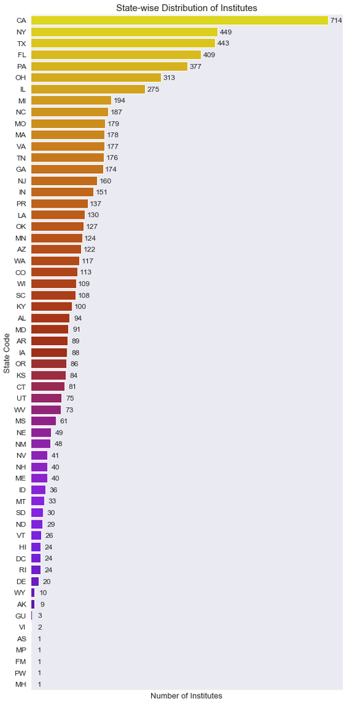

```python
sb.set_style('dark')
plt.figure(figsize = (8, 16))

# plot
ax = sb.barplot(df.stabbr.value_counts().values, list(df.stabbr.value_counts().index),
           palette = sb.color_palette('gnuplot_r', len(df.stabbr.value_counts())))

# annotate the bars
for p in ax.patches:
    width = p.get_width()
    plt.text(20+p.get_width(), p.get_y()+0.55*p.get_height(),
             '{:1.0f}'.format(width),
             ha='center', va='center', fontsize = 12)

# label the plot
plt.title('State-wise Distribution of Institutes', fontsize = 15)
plt.xlabel('Number of Institutes', fontsize = 13)
plt.ylabel('State Code', fontsize = 13)
plt.xticks([], [])
plt.yticks(fontsize = 12)

plt.tight_layout();
```

#### Q. What is the median number of branches per Institute?

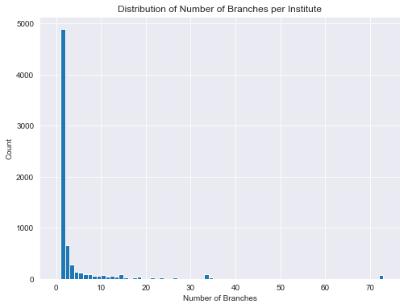

```python
sb.set_style('darkgrid')

# specify the bins
bins = np.arange(0, df.numbranch.max() + 1, 1)

# plot
plt.figure(figsize = (8,6))
plt.hist(data = df, x = 'numbranch', bins = bins)

# label
plt.title('Distribution of Number of Branches per Institute')
plt.xlabel('Number of Branches')
plt.ylabel('Count');
```

> - The median number of branches per Institute in the US is 1.
> - Strayer University has the highest number of branches.
> - The branches of Strayer University are spread across 16 states with the greatest number being in the state of Virginia.

#### Q. Which type of governance structure is the most common in the US across institutes?

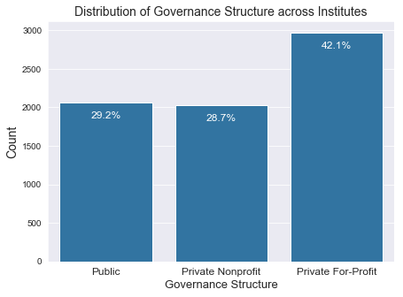

```python
# plot
plt.figure(figsize = (7, 5))
sb.countplot(data = df, x = 'control', color = sb.color_palette()[0])

# annotate
n_points = df.shape[0]
cat_counts = df.control.value_counts()
locs, labels = plt.xticks()                # get current tick locations and labels

# loop through each pair of locations and labels
for loc, label in zip(locs, labels):

    # get the text property for the label to get the correct count
    count = cat_counts[label.get_text()]
    pct_string = '{:0.1f}%'.format(100 * count / n_points)

    # print the annotations below the top of the bar
    plt.text(loc, count-200, pct_string, ha = 'center', color = 'w', fontsize = 12)

# label
plt.title('Distribution of Governance Structure across Institutes', fontsize = 14)
plt.xticks(fontsize = 12)
plt.xlabel("Governance Structure", fontsize = 13)
plt.ylabel('Count', fontsize = 14);
```

#### Q. How much do Institutions in the US make per student as tuition fee?

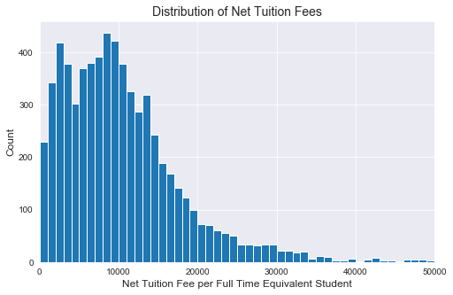

```python
plt.figure(figsize = (8,5))

# specify the bins
bins = np.arange(0, df.tuitfte.max() + 1000, 1000)

# plot
plt.hist(data = df, x = 'tuitfte', bins = bins);
plt.xlim(0,50000)

# label
plt.title('Distribution of Net Tuition Fees', fontsize = 14)
plt.xlabel('Net Tuition Fee per Full Time Equivalent Student', fontsize = 12)
plt.ylabel('Count', fontsize = 12);
```

Lets take a closer look at the institutes that earn less or more than the median amount per student:

```python
less_than_median = df.query('tuitfte < 9148').groupby('control').size().reset_index(name = 'count: tuitfte less than median')
more_than_median = df.query('tuitfte > 9148').groupby('control').size().reset_index(name = 'count: tuitfte more than median')

less_than_median.merge(more_than_median)
```

|  | control | count: tuitfte less than median | count: tuitfte more than median |
| --- | --- | --- | --- |
| 0 | Public | 1724 | 247 |
| 1 | Private Nonprofit | 435 | 1446 |
| 2 | Private For-Profit | 1137 | 1602 |

> - Most of the schools (about 92%) that earn more than the median (9148 dollars) per student are private entities.

#### Q. What is the median monthly Faculty Salary?

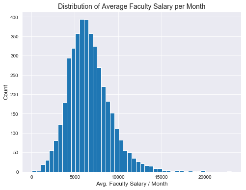

```python
# specify the bins
bins = np.arange(50, df.avgfacsal.max() + 500, 500)

# plot
plt.figure(figsize = (8, 6))
plt.hist(data = df, x = 'avgfacsal', bins = bins)

# label
plt.title('Distribution of Average Faculty Salary per Month', fontsize = 14)
plt.xlabel('Avg. Faculty Salary / Month', fontsize = 12)
plt.ylabel('Count', fontsize = 12);
```

> - On average, the median faculty salary is 6,377 per month.

#### Q. How is the distribution of admission rates across all institutes? In that, are admission rates on the higher, or lower side in the US?

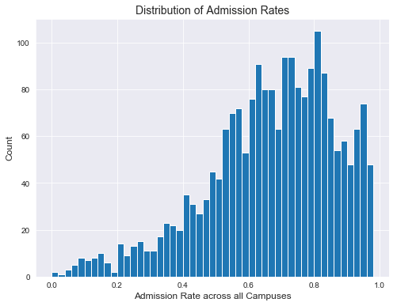

```python
# specify the bins
bins = np.arange(0, 1, 0.02)

# plot
plt.figure(figsize = (8,6))
plt.hist(data = df, x = 'adm_rate_all', bins = bins)

# label
plt.title('Distribution of Admission Rates', fontsize = 14)
plt.xlabel('Admission Rate across all Campuses', fontsize = 12)
plt.ylabel('Count', fontsize = 12);
```

> - The distribution seems to be clustered around certain discrete admission rates.
> - Also, it is left skewed which means, schools in the US tend to have admission rates on the higher side.

#### Q. What makes for a *good* or *bad* SAT or ACT score?

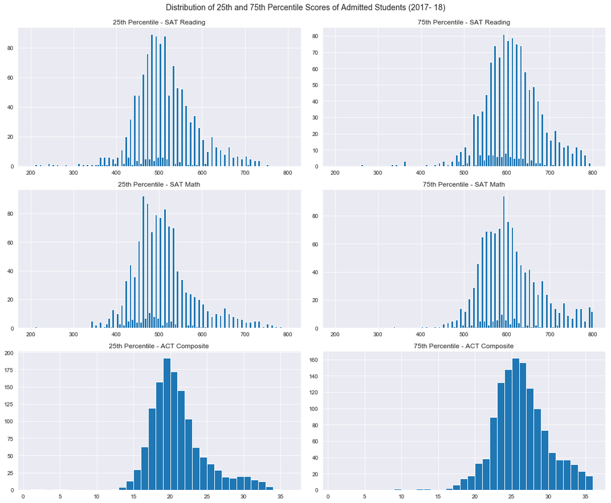

```python
# function to plot histograms
def hist(series, title, act = False):
    if act == True:
        bins = np.arange(1, 36 + 1, 1)  # the scale for ACTs is 1 - 36
        plt.hist(x = series, bins = bins)
        plt.title(title);
    else:
        bins = np.arange(200, 800 + 5, 5)  # the scale for SATs is 200 - 800
        plt.hist(x = series, bins = bins)
        plt.title(title);


# plot
plt.figure(figsize = (15, 12))

plt.subplot(3, 2, 1)
hist(df.satvr25, '25th Percentile - SAT Reading')

plt.subplot(3, 2, 2)
hist(df.satvr75, '75th Percentile - SAT Reading')

plt.subplot(3, 2, 3)
hist(df.satmt25, '25th Percentile - SAT Math')

plt.subplot(3, 2, 4)
hist(df.satmt75, '75th Percentile - SAT Math')

plt.subplot(3, 2, 5)
hist(df.actcm25, '25th Percentile - ACT Composite', act = True)

plt.subplot(3, 2, 6)
hist(df.actcm75, '75th Percentile - ACT Composite', act = True)

plt.suptitle('Distribution of 25th and 75th Percentile Scores of Admitted Students (2017- 18)',
            x = 0.5, y = 1.02, fontsize = 14)
plt.tight_layout();
```

> - We can see that the SAT scores are clustered in discrete bins. This is most likely due to the peculiarities of the Grading System such as fixed increments. On the other hand ACT scores seem to follow a normal distribution.
> - Most universities have their 75th Percentile for both Reading and Math fall around 600.
> - Similarly most universities have their 25th Percentile fall around 500.
> - From these observations it can be said that *a good **SAT** score falls in the range **500 - 600*** for both Reading and Math.
> - The distribution of ACT Composite Scores is generally normal with skews to the right and left for 25th and 75th percentiles respectively.
> - From the observations it can be said that *a good **ACT Composite** score is anywhere between **20 and 26**.*

### Bivariate Explorations

Here we will look for relationships between two variables at a time.

#### Q. How does admission rate of an institute affect the average faculty salary?

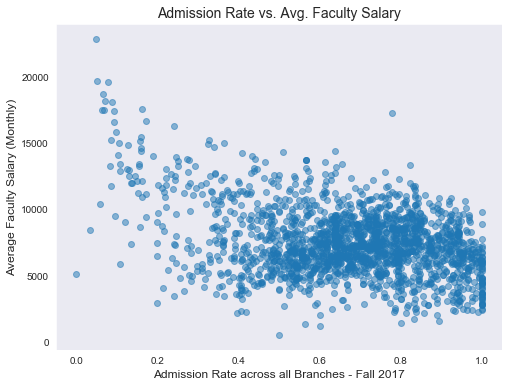

```python
sb.set_style('dark')

# plot
plt.figure(figsize = (8, 6))
sb.regplot(data = df, x = 'adm_rate_all', y = 'avgfacsal', fit_reg = False, scatter_kws = {'alpha':1/2})

# label
plt.title('Admission Rate vs. Avg. Faculty Salary', fontsize = 14)
plt.xlabel('Admission Rate across all Branches - Fall 2017', fontsize = 12)
plt.ylabel('Average Faculty Salary (Monthly)', fontsize = 12);
```

> - It can be observed that admission rate has a weak negative correlation (r = -0.35) with average faculty salary.

Lets zoom in on the institutes lying approximately in the upper left corner of the scatter plot where the admission rates are low and average faculty salary is high:

```python
df.query('avgfacsal > 15000 and adm_rate_all < 0.1')[['instnm', 'adm_rate_all', 'avgfacsal']].sort_values(by = 'avgfacsal')
```

|  | instnm | adm_rate_all | avgfacsal |
| --- | --- | --- | --- |
| 3175 | Brown University | 0.084925 | 15276.0 |
| 2486 | Duke University | 0.098588 | 15844.0 |
| 1022 | Northwestern University | 0.092380 | 16645.0 |
| 3093 | University of Pennsylvania | 0.092965 | 17435.0 |
| 630 | Yale University | 0.069254 | 17517.0 |
| 2112 | Princeton University | 0.064078 | 17519.0 |
| 925 | University of Chicago | 0.087347 | 18115.0 |
| 1567 | Massachusetts Institute of Technology | 0.071714 | 18182.0 |
| 2222 | Columbia University in the City of New York | 0.066084 | 18713.0 |
| 211 | California Institute of Technology | 0.077395 | 19600.0 |
| 1549 | Harvard University | 0.051562 | 19741.0 |
| 3953 | Stanford University | 0.047308 | 22924.0 |

> - As one might expect, institutes that have a very low admission rate and a very high average faculty salary are among the most notable institutes in the US.

#### Q. One might expect that institutes having a high 75th percentile of test scores for admitted students, would have low admission rates. Does the data support this assumption?

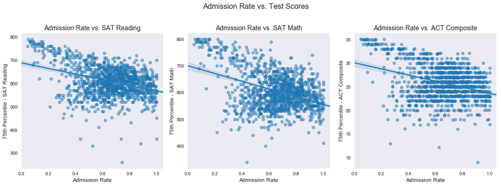

```python
plt.figure(figsize = (15, 5))

plt.subplot(1, 3, 1)
sb.regplot(data = df, x = 'adm_rate_all', y = 'satvr75', scatter_kws = {'alpha' : 1/2})
plt.title('Admission Rate vs. SAT Reading', fontsize = 14)
plt.xlabel('Admission Rate', fontsize = 12)
plt.ylabel('75th Percentile - SAT Reading', fontsize = 12)

plt.subplot(1, 3, 2)
sb.regplot(data = df, x = 'adm_rate_all', y = 'satmt75', scatter_kws = {'alpha' : 1/2})
plt.title('Admission Rate vs. SAT Math', fontsize = 14)
plt.xlabel('Admission Rate', fontsize = 12)
plt.ylabel('75th Percentile - SAT Math', fontsize = 12)

plt.subplot(1, 3, 3)
sb.regplot(data = df, x = 'adm_rate_all', y = 'actcm75', y_jitter = 0.1, scatter_kws = {'alpha' : 1/2})
plt.title('Admission Rate vs. ACT Composite', fontsize = 14)
plt.xlabel('Admission Rate', fontsize = 12)
plt.ylabel('75th Percentile - ACT Composite', fontsize = 12)

plt.suptitle('Admission Rate vs. Test Scores', x = 0.51, y = 1.1, fontsize = 16)
plt.tight_layout();
```

> - We can see here that institutes that have a low rate of admission tend to have a higher 75th percentile score, regardless of whether its the SAT or ACT.

#### Q. Are the highest awards also the predominant awards conferred at various institutes? Q. Is there a relationship between the highest award and the predominant award across schools?

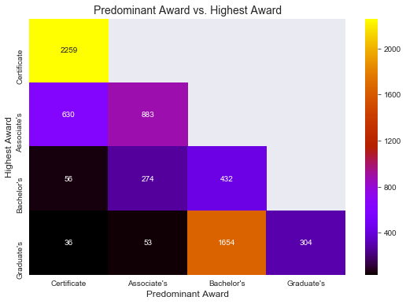

```python
# plot the shaped data with annotations
plt.figure(figsize = (9,6))
sb.heatmap(ct_counts, annot = True, fmt = '.0f',cmap = 'gnuplot')

# label
plt.title('Predominant Award vs. Highest Award', fontsize = 14)
plt.xlabel('Predominant Award', fontsize = 12)
plt.ylabel('Highest Award', fontsize = 12);
```

> - Institutes that offer a Certificate as their highest award also tend to have their predominant award as the same. There are 2259 such institutes that award Certificates only.
> - Institutes that offer a Graduate's Degree as their predominant award tend to have their highest award as the same. There are 304 such schools that award Graduate Degrees exclusively.
> - A Certificate is the most common award offered followed by a Bachelor's.
> - Institutes that offer a Graduate's Degree as their highest award most commonly qualify as predominantly Bachelor's granting institutes.

#### Q. Which type of institutes with regards to their governance structure admit younger or older students? Is there is perceptible pattern?

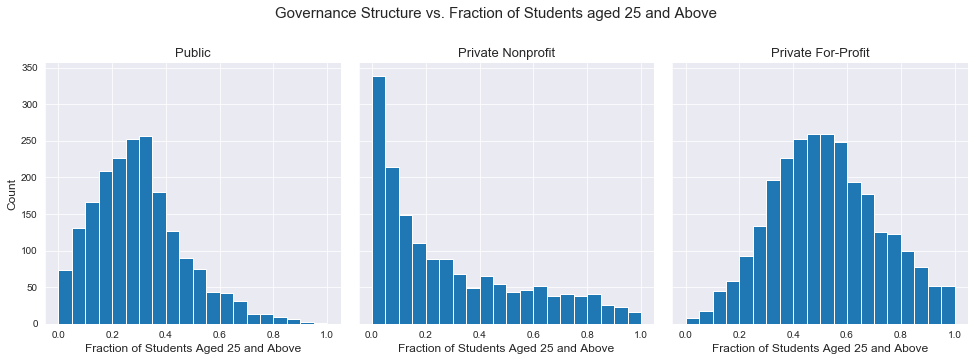

```python
sb.set_style('darkgrid')
# specify bins
bins = np.arange(0, 1 + 0.05, 0.05)

# create a FacetGrid object
g = sb.FacetGrid(data = df, col = 'control', height = 4.5)

# plot
g.map(plt.hist, 'ug25abv', bins = bins)

# label
g.set_titles('{col_name}', size = 13)
g.set_xlabels('Fraction of Students Aged 25 and Above', fontsize = 12)
g.set_ylabels('Count', fontsize = 12)
plt.suptitle('Governance Structure vs. Fraction of Students aged 25 and Above', fontsize = 15, x = 0.5, y = 1.1);
```

> - For Public schools the median percentage for students aged twenty five and above is 28.
> - For Private For-Profit schools the median percentage for students aged twenty five and above is 50.
> - While Private Nonprofits have the youngest population of students with the median percentage of students aged twenty five and above being 19.

#### Q. Students in which type of institutes with regards to their governance structure are more likely to receive a federal loan?

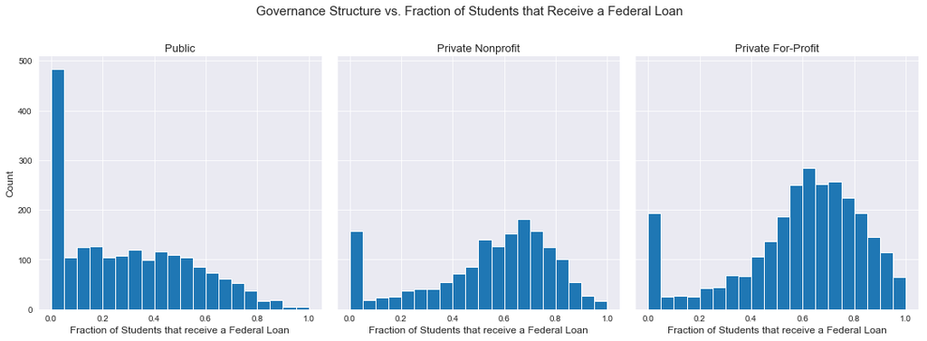

```python
# specify the bins
bins = np.arange(0, 1 + 0.05, 0.05)

# create a FacetGrid object
g = sb.FacetGrid(data = df, col = 'control', height = 5)

# plot
g.map(plt.hist, 'pctfloan', bins = bins)

# label
g.set_titles('{col_name}', size = 13);
g.set_xlabels('Fraction of Students that receive a Federal Loan', fontsize = 12)
g.set_ylabels('Count', fontsize = 12)
plt.suptitle('Governance Structure vs. Fraction of Students that Receive a Federal Loan', fontsize = 15, x = 0.5, y = 1.1);
```

> - The distribution for Private Nonprofit and Private For-Profit institutes looks similar. We have taller bins for For-Profits owing to a greater number of such schools in the US. Generally speaking, a similar percentage of students from both these institutes receive a federal loan.
> - Students from Public Schools are least likely to receive federal loans. A large fraction of students from these institutes do not receive a federal loan at all.

#### Q. How do faculty in Distance-only Institutes earn as compared to institutes that offer both Distance and On-campus education?

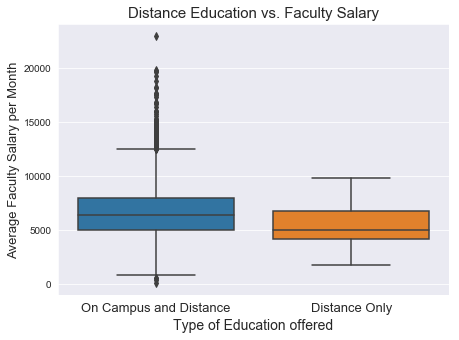

```python
# plot
plt.figure(figsize = (7, 5))
sb.boxplot(data = df, x = 'distanceonly', y = 'avgfacsal')

# rename tick labels
plt.xticks([0, 1], ['On Campus and Distance', 'Distance Only'], fontsize = 13)

# label
plt.title('Distance Education vs. Faculty Salary', fontsize = 15)
plt.ylabel('Average Faculty Salary per Month', fontsize = 13)
plt.xlabel('Type of Education offered', fontsize = 14);
```

> - We can see that on average the median salary of faculty in institutes that offer Distance-only education is about 1,500 less per month as compared to faculty from institutes that offer both Distance and On-campus learning.
> - It is also worth noting that there is greater variability in the average faculty salary for institutes that offer On-campus education as compared to Distance-only institutes.

### Multivariate Explorations

Here we will look at the interaction of three or more variables simultaneously.

#### Q. One may think the institutes that admit students with higher SAT scores would have a low admission rate. Let's see if we can corroborate that with data.

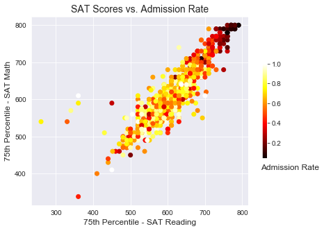

```python
# plot
plt.figure(figsize = (7, 5))
plt.scatter(data = df, x = 'satvr75', y = 'satmt75', c = 'adm_rate_all', cmap = 'hot')

# add a colorbar
plt.colorbar(shrink = 0.5)

# label
plt.title('SAT Scores vs. Admission Rate', fontsize = 14)
plt.xlabel('75th Percentile - SAT Reading', fontsize = 12)
plt.ylabel('75th Percentile - SAT Math', fontsize = 12)
plt.text(x = 850, y = 410, s = 'Admission Rate', size = 12);
```

> - We can see that our assumption was true. The dark datapoints on the upper right of the scatter plot represent the most selective institutes in the US. These institutes require higher SAT scores but even then have a very low admission rate.
> - It is worh noting that there are certain datapoints on the lower side of the SAT spectrum that have a low admission rate. These institutes even though selective, do not necessarily require students to have high SAT scores.

#### Q. Does the 75th Percentile Score across all institutes correlate over different tests?

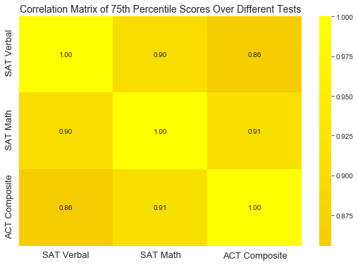

```python
plt.figure(figsize = (9, 6))

# separate out the columns of interest and rename appropriately
tests75 = df[['satvr75', 'satmt75', 'actcm75']].rename({'satvr75':'SAT Verbal', 'satmt75':'SAT Math',
                                                       'actcm75':'ACT Composite'}, axis = 'columns')
# plot
sb.heatmap(tests75.corr(),
            annot = True, fmt = '.2f', cmap = 'gnuplot', center = 0)

# adjust tick locations and fontsize
plt.yticks([0.2, 1.25, 2.1], fontsize = 13)
plt.xticks(fontsize = 13)

# label
plt.title('Correlation Matrix of 75th Percentile Scores Over Different Tests', fontsize = 14);
```

> - We can see there is a strong correlation between the 75th Percentile score on different tests across institutes.
> - We can state that if a certain institute has a high 75th Percentile for any one of the tests, it is very likely that the 75th percentile for the other tests will be high as well.

#### Q. Which type of institutes with regards to governance structure see the highest number of undergraduate enrollments? What percentage of these students are aged 25 and above?

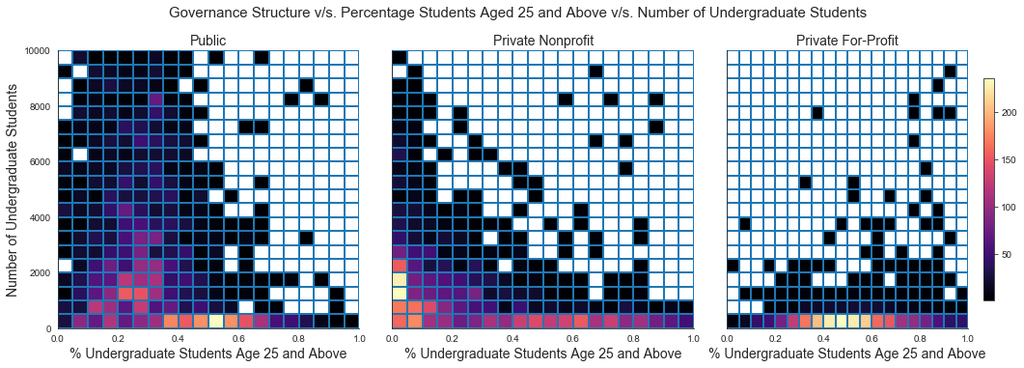

```python
sb.set_style('white')

# define bin sizes
bins_x = np.arange(0, 1 + 0.05, 0.05)
bins_y = np.arange(0, 10000 + 500, 500)

# create FacetGrid object
g = sb.FacetGrid(data = df.query('ugds<10000'),                    # ugds > 10000 are mostly Distance Only schools;
                                                                   # we are excluding them to observe a distinguishable pattern
                 col = 'control', height = 5, despine = True)

# Plot/Map FacetGrid Object
g.map(plt.hist2d, 'ug25abv', 'ugds', cmin = 0.5, cmap = 'magma', bins = [bins_x, bins_y])

# label
g.set_titles('{col_name}', size = 14)
g.set_xlabels('% Undergraduate Students Age 25 and Above', fontsize = 14)
g.set_ylabels('Number of Undergraduate Students', fontsize = 14)
plt.colorbar(shrink = 0.8)
plt.suptitle('Governance Structure v/s. Percentage Students Aged 25 and Above v/s. Number of Undergraduate Students',
             fontsize = 15, x = 0.5, y = 1.05)
plt.tight_layout();
```

> - We can observe by far that the highest number of enrollments of Undergraduates happen in Public Schools. On average, 30% of these students are aged 25 and above.
> - The youngest population on average can be seen in Private Nonprofits.
> - Private For-Profits see comparatively few undergraduate enrollments. However, these institutes on average have the highest percentage of students aged 25 and above.

## Limitations

- For this analysis we have chosen to study the data for the academic year from Fall '17 to Fall '18. Some of the patterns that we saw here may not exist for other years.
- Only 17% of the institutes in the dataset have reported data on their test scores. This puts severe limitations on our analysis where we try to answer the question "what qualifies as a good SAT or ACT score".
- Similar is the case with data on Admission Rates where only about 32% of the schools have provided the data. This puts limitations on our analysis where we try to answer questions like "how do admission rates affect average faculty salary across schools" or when we visualize the distribution of admission rates.
- A number of data fields such as Avg. Faculty Salary and Tuition Fee are average values. We perform our analysis on these average values. Needless to say, average experience isn't always the experienced average.
- For the entire data for academic year 2017 - 18, we have chosen a subset of data fields to analyze. This analysis is in no way the complete picture of the U. S. Educational system.

## Conclusions

Here we will highlight the main findings of our survey of the U. S. Education System for the academic year Fall '17 to Fall '18.

#### Academic Trends

1. From the limited data available we can say that a good SAT score falls in the range 500 - 600 for both Reading and Math while a good ACT Composite score can be anywhere between 20 and 26.
2. Required Test Scores and Average Faculty Salary across schools have a weakly negative correlation with Admission Rate. Meaning, schools that have a high admission rate have lower requirements on test scores and tend to pay less to their faculty on average as compared to schools with lower rates of admission.
3. Although the above trend is largely ubiquitous, there are some outlier institutes that have a low admission rate even though their requirements on test scores are relatively low. These institutes give less weightage to test scores while admitting students.
4. Certificate Programs are the most common in the US followed by Bachelor's Degrees.